# How can the effectiveness of scare-off measure on wild boar be measured?

Semesterproject 022, Patterns and Trends in Environmental Data - Computational Movement Analysis

Mathujah Manikkan and Gioele Pinana

## Abstract

Over the past few years, the population of wild boars in Switzerland has increased rapidly. As the number of wild boars increases, so does the damage to agriculture, as they seek for food in the fields. To counteract this damage, new preventive measures such as hunt, schreck, staged shots and so on have been developed with the aim of preventing the wild boars from entering the fields. Within this semester project we want to measure the effectiveness of the scare-off measure schreck. The Zurich University of Applied Sciences provided us with three datasets for our research. One dataset contains the coordinates of 98 wild boars in Fenel in region of Bern, Switzerland over the period from May 2014 to October 2016. The other two datasets contains the coordinates of the scare positions and time intervals when the scare was turned on and off. To investigate the question of their effectiveness, two different methods are analyzed and at the end critically discussed on their advantages and disadvantages.

## Introduction

Until 1945, only a few animals arrive in Switzerland from Germany, France and Italy. Between 1945 and 1952 more frequent wild boars were then recorded in Switzerland. However, the population was not able to establish itself until between 1970 and 1990. Since 1990, the population of wild boars has been growing strongly, as evidenced by the number of animals shot and killed in traffic accidents. Possible reasons for the strong population increase are milder winters, an additional number of fattening years as well as the almost inexhaustible and mostly freely available food supply on agricultural land. Based on the planned realization of wildlife passages, it is assumed that the population will expand in the Central Plateau as well as in the Pre-Alps in the next few years. (Graf R.F and Fischer C.(Hrsg.), 2021)

Wild boars are omnivores and spend a large part of their time searching for food, covering an average of 5 km per night. Wild boars are mainly active during the night and as the only representative of the cloven-hoofed animals, they can reach food in the ground. To do this, it digs up the top layer of soil to a depth of 20-60 cm with its snout disc, which is ideally suited for this purpose. In the soil wild boars find large quantities of invertebrates and roots, but also mice, the nests and supplies. Wild boars also find a large part of their food on agricultural land. Particularly popular are corn, wheat and canola. Over the summer and in the fall wild boars eat fat, from which they can then feed over the meager winter months and also in the spring. Wild boars are very loyal to their location, but do not defend a territory. Thus, several herds can be on the move in the same area. Aggressive behavior between the rods occurs only when they occur at the same time at a food source. Depending on the region, the activity areas vary in size, with 2.5-12 km2 for males and 4.5-30 km2 for does. (Graf R.F and Fischer C.(Hrsg.), 2021)

Agricultural fields can be protected with prevention methods such as electric fencing clasping closures and hunt (Graf R.F and Fischer C.(Hrsg.), 2021). However, there is currently no prevention method that works 100%. Potential reasons for this can be related to the different behavioral and movement patterns of wild boar. Since the existing methods are still complex and expensive, researchers at the Zurich University of Applied Sciences have therefore developed an acoustic method called “Schreck”. In this method, alarm and warning calls of wild boars are reproduced in order to keep wild boars away from entering fields and prevent damage. The acoustic wild boar scare now provides a flexible and intelligent prevention method. This thesis examines the effectiveness of this new prevention method in order to enable sustainable wild boar management (Suter S. 2013).This can not only prevent direct conflicts, but also indirectly limit accessible population growth. (Graf R.F and Fischer C.(Hrsg.), 2021)

## Material and Methods

Within this semester project, two methods are examined to investigate the effectiveness of the scaring method. The strengths and weaknesses of the methods are then compared and critically discussed. The following data sets are necessary for this method comparison:

### Datasets

#### Dataset wildschweine_BE

The Zurich University of Applied Sciences provided us with tree required datasets for our research. The dataset “wildschwein_BE” contains the coordinates of 98 wild boars in Fenel in region of Bern, Switzerland over the period from May 2014 to October 2016. As can be seen from the following table, the coordinates of the wild boars were collected every 15 minutes. Each fix point in the dataset contains the apperent attributes (TierID, TierName, CollarID, DatetimeUTC, E, N, day and moonilumination)

sample of dataset wildschweine_BE

| TierID | TierName | CollarID | DatetimeUTC | E | N | day | moonilumination |
| --- | --- | --- | --- | --- | --- | --- | --- |
| 1 | Ueli | 12272 | 2014-05-28 21:01:14 | 2570390 | 1204820 | Tag | 0.0033556 |
| 1 | Ueli | 12272 | 2014-05-28 21:15:18 | 2570389 | 1204826 | Abenddaemmerung | 0.0033556 |
| 1 | Ueli | 12272 | 2014-05-28 21:30:13 | 2570391 | 1204821 | Abenddaemmerung | 0.0033556 |
| 1 | Ueli | 12272 | 2014-05-28 21:45:11 | 2570388 | 1204826 | Abenddaemmerung | 0.0033556 |
| 1 | Ueli | 12272 | 2014-05-28 22:00:33 | 2570388 | 1204819 | 1Nachtviertel | 0.0033556 |
| 1 | Ueli | 12272 | 2014-05-28 22:15:16 | 2570384 | 1204828 | 1Nachtviertel | 0.0033556 |

#### Dataset schreck_locations and schreck_agenda

The second “schreck_locations” and third “schreck_agenda” datasets contain the coordinates of the schreck-positions and time intervals when the scare was turned on and off. In a futher step, the two data sets were joined into one data set using a left join.

**Schreck_locations:** Each fix point in the dataset contains the apperent attributes (id, region, flurname, kultur, installationshohe, zaun, jagddruck, lat and lon)

sample of dataset schreck:locations

| id | region | flurname | kultur | installationshohe | zaun | jagddruck | lat | lon |
| --- | --- | --- | --- | --- | --- | --- | --- | --- |
| WSS_2014_01 | elfingen | rüti | weizen&hafer | 1.80 | nein | mittel | 47.51406 | 8.095919 |
| WSS_2014_02 | elfingen | steiacher | weizen | 1.95 | nein | mittel | 47.49951 | 8.122986 |
| WSS_2014_03 | elfingen | schlotterbode | weizen&sorgungras | 1.80 | nein | mittel | 47.50564 | 8.110089 |
| WSS_2014_04 | fanel | tannenhof | kartoffeln&mais | 1.80 | ja | gering | 46.99720 | 7.056506 |
| WSS_2014_05 | fanel | tannenhof | karotten&kartoffeln | 1.80 | nein | gering | 46.99433 | 7.058764 |
| WSS_2014_06 | fanel | fanelacher | kartoffeln&mais&zuckerrueben | 1.80 | nein | gering | 47.01424 | 7.039208 |

**Schreck_agenda:** Each fix point in the dataset contains the apperent attributes (id, datum_on, datum_off, modus, lautstaerke, intervall, ausrichtung_min, ausrichtung_max and phase)

sample of dataset schreck_agenda

| id | datum_on | datum_off | modus | lautstaerke | intervall | ausrichtung_min | ausrichtung_max | phase |
| --- | --- | --- | --- | --- | --- | --- | --- | --- |
| WSS_2014_01 | 2014-04-01 | 2014-06-20 | standard v1 | 100 | 15 | 80 | 280 | 2 |
| WSS_2014_01 | 2014-07-23 | 2014-09-19 | standard v1 | 100 | 15 | 80 | 280 | 2 |
| WSS_2014_02 | 2014-04-26 | 2014-08-08 | standard v1 | 50 | 4 | 45 | 225 | 2 |
| WSS_2014_03 | 2014-04-26 | 2014-08-08 | standard v1 | 100 | 15 | 30 | 180 | 2 |
| WSS_2014_03 | 2014-09-19 | 2014-10-18 | standard v1 | 50 | 20 | 30 | 180 | 2 |
| WSS_2014_04 | 2014-05-01 | 2014-10-28 | standard v1 | 33 | 15 | 200 | 280 | 2 |

### Pre-processing

#### Dataset wildschweine_BE

Based on a sampling analysis, GPS collars for wild boar are aheaded to a complex sampling procedure. This can be seen in the following figure, where the temporal overlap of of 19 wild boards is shown. Based on this graph, we can see which wild boars are suitable for our analysis. This chart gives us a rough overview of the wild boar data and helps us to understand the wild boars were caught sequentially and some of them overlap.

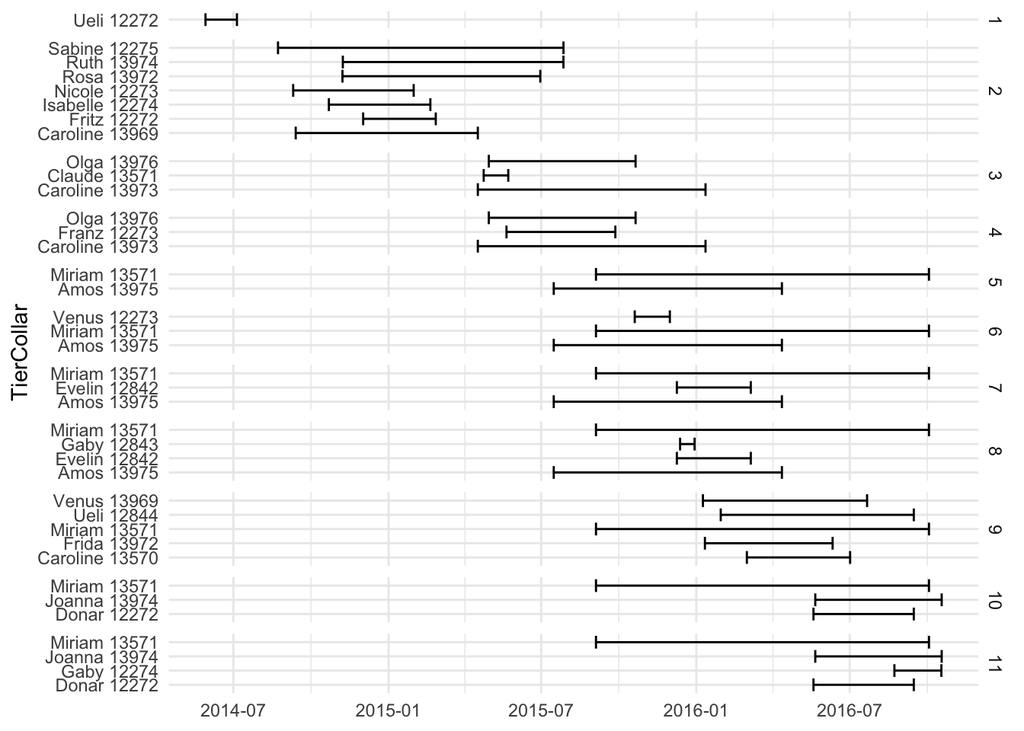

Temporal overlap from 19 wild boars in the region Fenel

A spatial overlay analysis was created to identify the movement behavior of wild boars. The plot is attached in the Appendix A. Afterwards the coordinates of the schreck locations from GPS to CH1903+ / LV95 were changed. For this purpose, the dataframe was first transformed into a spatial object. Using different spatial plots of the wild boars as well as the schreck coordinates, suitable schreck locations were manually selected. These following list of schrecks-ID are suitable for our analysis:*(WSS_2016_05, WSS_2016_01, WSS_2016_13, WSS_2016_06, WSS_2015_01, WSS_2015_03, WSS_2015_04, WSS_2014_04, WSS_2014_05, WSS_2014_06, WSS_2017_02, WSS_2017_01, WSS_2017_09, WSS_2017_07, WSS_2017_03, WSS_2017_04)*

The dataframe was now filtered on the basis of the selected schrecks. In order to analyze the wild boars individually, in a further step singel dataframes with the respective names of the wild boars were created. Since the dataset “wildboar_BE” contains 98 different wild boars, only 19 wild boars were selected for working further in this analysis. The selected wild boars are (Ueli, Sabine, Caroline, Isabelle, Rosa, Ruth, Miriam, Fritz, Claude, Franz, Amos, Nicole, Venus, Evelin, Gaby, Frida, Donar, Joanna).

### Methods

For this study, two different methods with different approaches were selected in order to verify the effectiveness of the schreck. In order to compare both methods with each other, it was necessary to have the same initial situation and to use the same data. For this purpose, in a first step, a suitable schreck with a high coverage of different wild boar presence was selected on the basis of the introduced data sets. Afterwards, three wild boars were selected for this method comparison on the basis of the selected schreck.

For our analysis, based on the above criteria, the scare **WSS_2016_01** as well as the three wild boars **Caroline, Miriam and Frida** were selected as an ideal starting point for the method comparison. The following plot shows the trajectories of the three boars represented as black points. WSS_2016_01 is shown as a yellow dot. The red dots indicate other schreck-locations, which are not as suitable for our analysis as WSS_2016_01 and are therefore discarded. Appendix B shows an interactive map of the three selected wild boar home ranges.

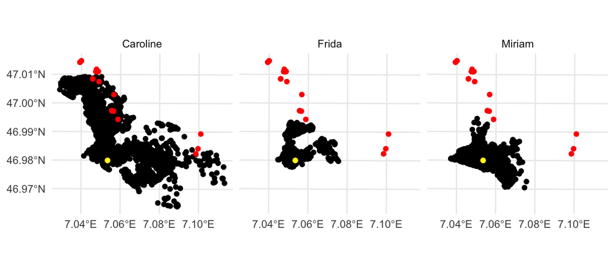

By looking at the scare data it turned out that the scare was powered on for some days. Therefore this method compares the mean distance between wild boar and schreck-location during three diffrent timeperiods:

1. Time period: Before the schreck was turned on (called: off before)
2. Time period: When the schreck was turned on (called: on)
3. Time period: After the schreck was turned off (called: off after)
- **Methode (1):** The first approach compares the mean distance between wild boar and schreck-locations in the three different time periods. For this purpose, the distances from all data points of the three wild boars to the scare were calculated. These distances were afterwards statistically compared by using an one-way anova and a boxplot.
- **Methode (2):** The second approach analyzes the presence of wild boars by selected agricultural fields. Therefore, the data package “Feldaufnahmen_Fanel” was additionally used, which subdivides the land cover resp. the type of agricultural area of the nature reserve Fanel. It is examined which wild boars were observed in the selected field before the activation of the scare and if and how often they were observed in the same field after the activation.

### Problems and limitations

In our analysis, three female wild boars were selected based on their movement patterns. Since the behavior of female and male wild boars differs, the analysis with male wild boars would have been quite useful as a comparison. However, this was not possible within the framework of this work, but it may be considered for a future work.

## Results

### Method 1

The boxplot as well as the static evaluation of the single factorial anova showed that there is a significant difference in the mean distance to the scare WSS_20216_01 in the time periods. Based on this method, it is confirmed that the scare has an effect on the wild boars.

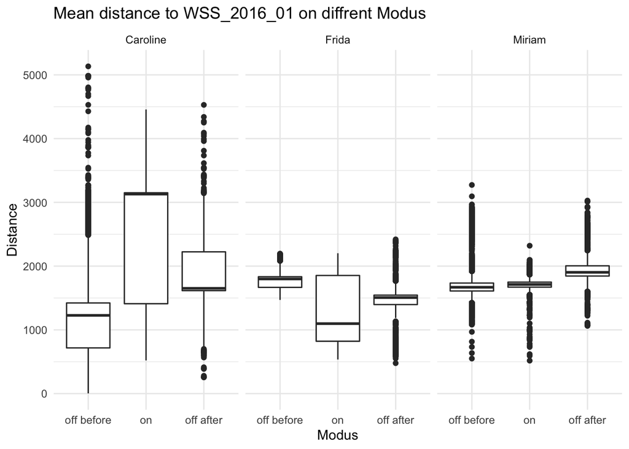

ANOVA (One-Way)

```
##                Df    Sum Sq   Mean Sq F value Pr(>F)
## Schreck         2 5.018e+09 2.509e+09    7484 <2e-16 ***
## Residuals   56022 1.878e+10 3.353e+05
## ---
## Signif. codes:  0 '***' 0.001 '**' 0.01 '*' 0.05 '.' 0.1 ' ' 1
```

```
##                Df    Sum Sq   Mean Sq F value Pr(>F)
## Schreck         2 5.654e+08 282682726    9896 <2e-16 ***
## Residuals   42616 1.217e+09     28565
## ---
## Signif. codes:  0 '***' 0.001 '**' 0.01 '*' 0.05 '.' 0.1 ' ' 1
```

```
##                Df    Sum Sq   Mean Sq F value Pr(>F)
## Schreck         2 6.744e+08 337213903    4182 <2e-16 ***
## Residuals   14537 1.172e+09     80627
## ---
## Signif. codes:  0 '***' 0.001 '**' 0.01 '*' 0.05 '.' 0.1 ' ' 1
```

### Method 2

The following plot shows a reduced extract of Fanel’s land use area. It can be concluded that the suitable schreck WSS_2016_01 is located on the grassland area No.2 (German: Wiese Nr. 2). Grassland areas are optimal for our research question, since wild boars spoil the ground during their search for food.

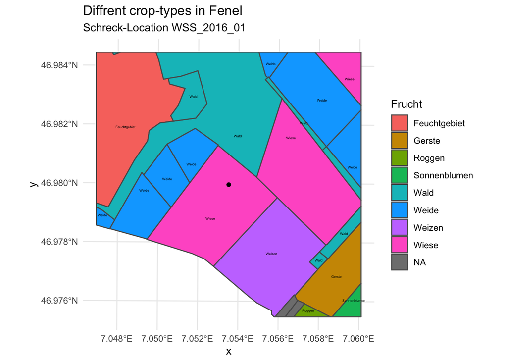

The data frames from the three wild boars were joined with the “crop_fanel” data frame. From this, it was possible to calculate how often the three wild boars were present in the grassland area at the respective time periods. Appendix C shows the percentage presence of the three wild boars in the most frequently used agricultural areas in Fenel.

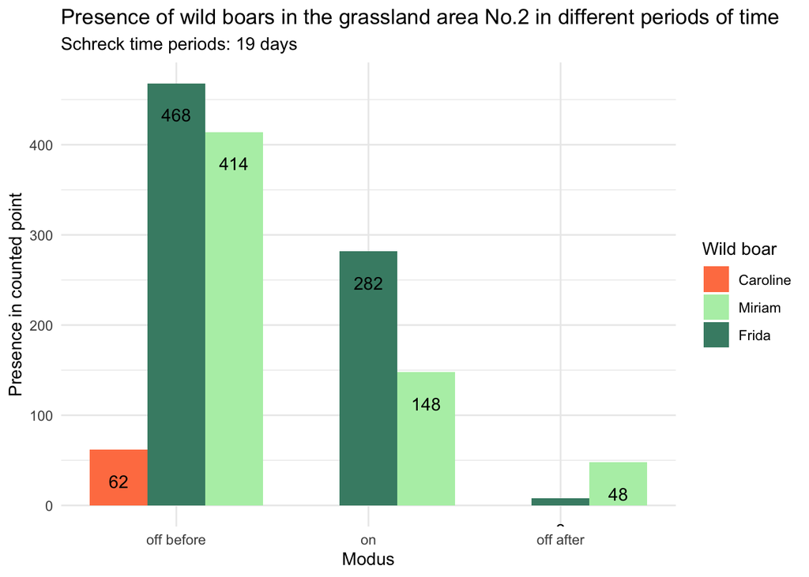

Presence of wild boars in the grassland area No.2 in different periods of time

## Discussion

### Conclusion of the results

The evaluation of both methods show that the schreck had different effects between the two methods but also among the wild boars themselves.

The evaluations of method 2 show that Caroline was on grassland area no. 2 in the 1st time period. However, she did not appear in the other two time periods, which indicates the best possible effect of the schreck The two other wild boars Frida and Miriam showed a similar behavior. Both were in the 1st time period at the most on the grassland area. When the schreck started, their presence reduced though. In the 3rd time period their presence was finally the least.

### Conclusion of the methods

Both methods compare interesting aspects of the behavior of wild boars. The method 1 has the advantage to include far distances also outside a certain area in the analysis. In method 2 it was only counted if the wild boars were on the selected area. Whether they were immediately on the surrounding area was not evident in this analysis. Another advantage of method 1 is that it was confirmed by a statistical test. Disadvantages of method 1 show the large number of outliers that were seen in practically all wildlife. Method 2 examines the problem in relation to an area, which is also of considerable use in reality. The damage caused by the wild boars is related to certain types of areas. Using method 2, an effect can be selectively predicted. Since a wild boar that is in the vicinity is more likely to return to the area than one that is several km away, it would be useful to include a neighborhood analysis in a follow-up study as an extension and strengthening of method 2.

## Reference

- Graf, Roland; Fischer, Claude, Hrsg., 2021. Atlas der Säugetiere : Schweiz und Liechtenstein. Bern: Haupt, Schweizerische Gesellschaft für Wildtierbiologie. ISBN 978-3-258-08178-6.
- Suter, S. (2013): Forschungsprojekt: Prävention von Wildschweinschäden in der Landwirtschaft https://www.aramis.admin.ch/Default?DocumentID=3369&Load=true

## Appendix

**Appendix A**

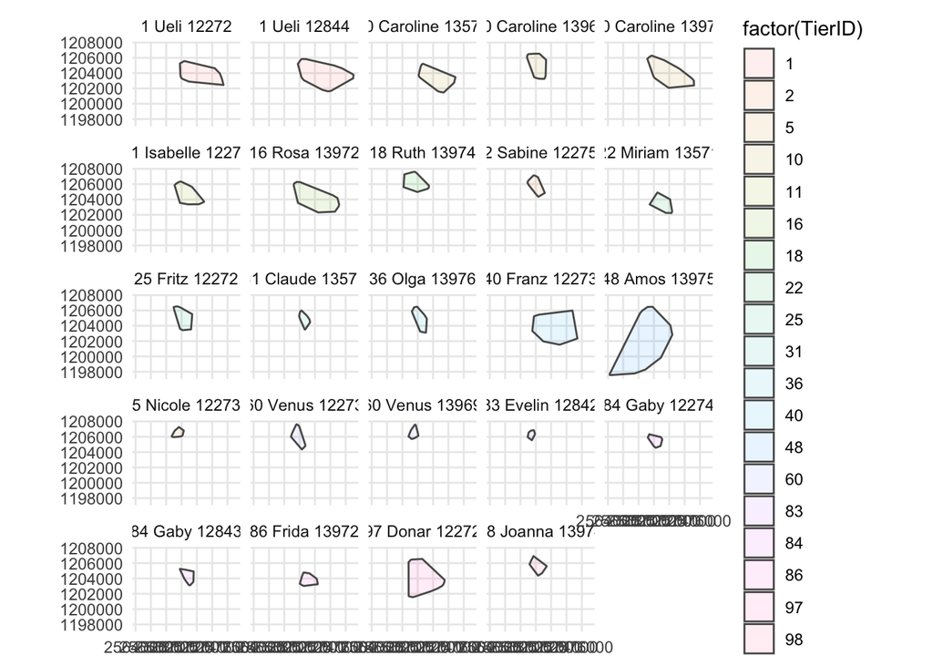

Spaital overlap from 19 wild boars in the region Fenel

**Appendix B**

[interactive chart not shown]

**Appendix C**

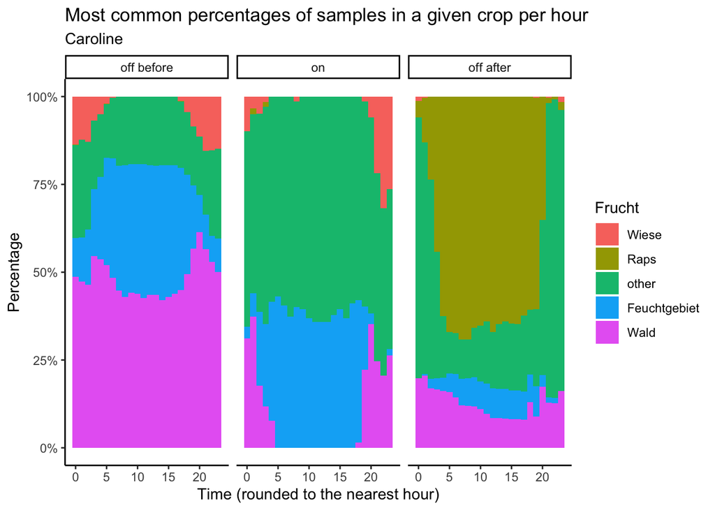

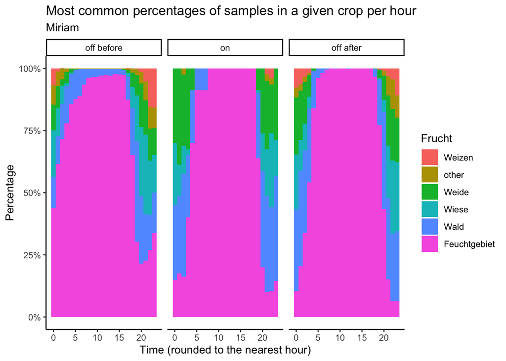

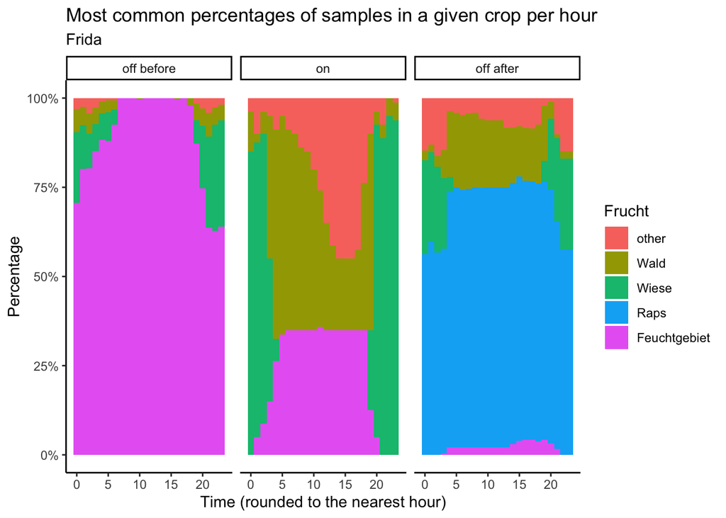